# Predicting Customer Cancellation from Telecom Services

```r
# Suppress dplyr summarise grouping warning messages
options(dplyr.summarise.inform = FALSE)

## Add R libraries
library(tidyverse)
library(tidymodels)
library(dplyr)
library(ggplot2)
library(ggpubr)
library(reshape2)
library(discrim)
library(klaR)
library(tune)
library(kknn)
library(vip)
library(MASS)


# Load the dataset
telecom_df <- readRDS(url('https://gmubusinessanalytics.netlify.app/data/telecom_df.rds'))
```

```r
skimr::skim(telecom_df)
```

Data summary

| Name | telecom_df |
| --- | --- |
| Number of rows | 1175 |
| Number of columns | 19 |
| _______________________ |  |
| Column type frequency: |  |
| factor | 15 |
| numeric | 4 |
| ________________________ |  |
| Group variables | None |

**Variable type: factor**

| skim_variable | n_missing | complete_rate | ordered | n_unique | top_counts |
| --- | --- | --- | --- | --- | --- |
| canceled_service | 0 | 1 | FALSE | 2 | no: 748, yes: 427 |
| senior_citizen | 0 | 1 | FALSE | 2 | no: 944, yes: 231 |
| spouse_partner | 0 | 1 | FALSE | 2 | no: 633, yes: 542 |
| dependents | 0 | 1 | FALSE | 2 | no: 878, yes: 297 |
| cellular_service | 0 | 1 | FALSE | 2 | mul: 639, sin: 536 |
| internet_service | 0 | 1 | FALSE | 2 | fib: 781, dig: 394 |
| online_security | 0 | 1 | FALSE | 2 | no: 775, yes: 400 |
| online_backup | 0 | 1 | FALSE | 2 | no: 678, yes: 497 |
| device_protection | 0 | 1 | FALSE | 2 | no: 652, yes: 523 |
| tech_support | 0 | 1 | FALSE | 2 | no: 805, yes: 370 |
| streaming_tv | 0 | 1 | FALSE | 2 | yes: 608, no: 567 |
| streaming_movies | 0 | 1 | FALSE | 2 | no: 622, yes: 553 |
| contract | 0 | 1 | FALSE | 3 | mon: 771, one: 204, two: 200 |
| paperless_bill | 0 | 1 | FALSE | 2 | yes: 819, no: 356 |
| payment_method | 0 | 1 | FALSE | 4 | ele: 509, ban: 253, cre: 240, mai: 173 |

**Variable type: numeric**

| skim_variable | n_missing | complete_rate | mean | sd | p0 | p25 | p50 | p75 | p100 | hist |
| --- | --- | --- | --- | --- | --- | --- | --- | --- | --- | --- |
| avg_call_mins | 0 | 1 | 350.72 | 73.64 | 52.00 | 306.50 | 351.00 | 400.00 | 562.0 | ▁▂▇▇▁ |
| avg_intl_mins | 0 | 1 | 106.23 | 31.82 | 15.00 | 84.00 | 106.00 | 127.00 | 231.0 | ▁▇▇▂▁ |
| months_with_company | 0 | 1 | 31.04 | 24.46 | 1.00 | 8.00 | 26.00 | 54.00 | 72.0 | ▇▃▃▃▅ |
| monthly_charges | 0 | 1 | 81.90 | 18.52 | 43.45 | 69.88 | 83.85 | 95.97 | 118.6 | ▅▅▇▇▃ |

# Data Analysis

There are 427 customers who has cancelled the services and which contributes to 36.3% to the population

```r
cancel_percent_df
```

| canceled_service | total | percent_cancel |
| --- | --- | --- |
| yes | 427 | 36.3 |
| no | 748 | 63.7 |

# Question 1

**Question**: Is there any relation between canceled service, months_with_company and monthly_charges?

**Answer**: The customers who have cancelled the service show a high variation w.r.t the months with the company. However, the monthly charges doesn’t seem to affect much to the cancellation of the service

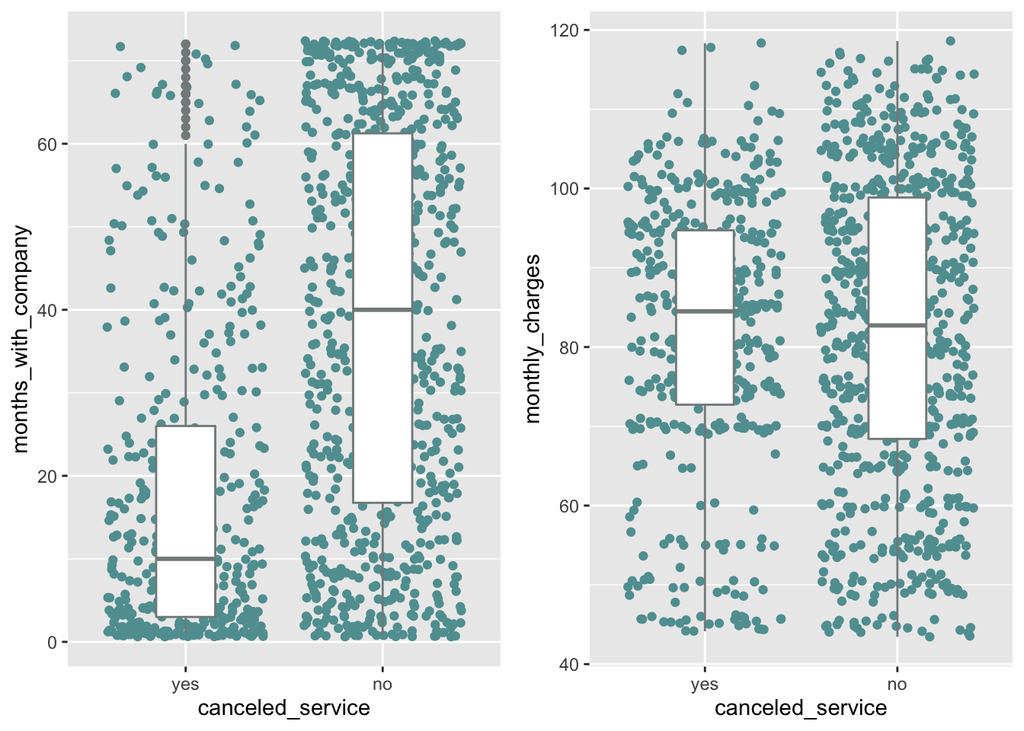

```r
plot_comp <- ggplot(data = telecom_df, aes(x= canceled_service , y = months_with_company)) +
  geom_jitter(color = "cadetblue") +
  geom_boxplot(width = 0.3, color = "azure4")

plot_charge <- ggplot(data = telecom_df, aes(x = canceled_service, y =  monthly_charges)) +
  geom_jitter(color = "cadetblue") +
  geom_boxplot(color = "azure4", width = 0.3)

ggarrange(plot_comp,plot_charge, nrow=1 )
```

# Question 2

**Question**: Do cancelled service has any relation with avg_call_mins and avg_intl_mins?

**Answer**: It can be said that the customers who are making more international calls seems to continue with the subscription as compared to the customers who do less international calls. On the other hand, the customers who make more calls on a average tends to cancel the service. This means that majority of them can be local calls cancelling the service

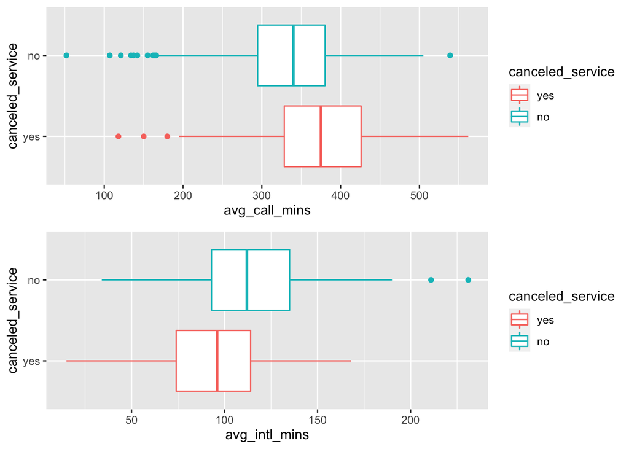

```r
plot_call <- ggplot(telecom_df, aes(y = canceled_service,
                    x = avg_call_mins, color = canceled_service)) + geom_boxplot()

plot_int <- ggplot(telecom_df, aes(y = canceled_service,
                    x = avg_intl_mins, color = canceled_service)) + geom_boxplot()

ggarrange(plot_call, plot_int, nrow = 2, ncol = 1)
```

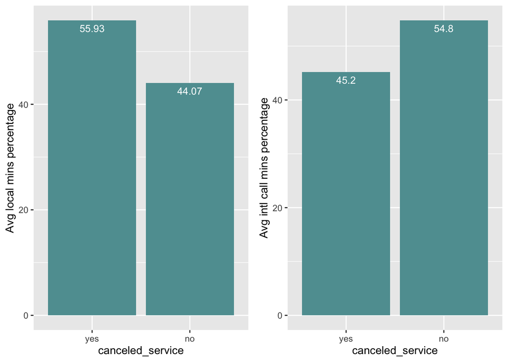

```r
calling_data <- telecom_df %>% dplyr::select(canceled_service,
                                             avg_call_mins, avg_intl_mins)

calling_data$local <- calling_data$avg_call_mins - calling_data$avg_intl_mins

perc_local <- calling_data %>%
  group_by(canceled_service) %>%
  summarise(avg = mean(local)) %>%
  mutate(perct = round(avg/sum(avg)*100,2))

# call <- telecom_df %>%
#   group_by(canceled_service) %>%
#   summarise(avg = mean(avg_call_mins)) %>%
#   mutate(perct = round(avg/sum(avg)*100,2))

intl <- telecom_df %>%
  group_by(canceled_service) %>%
  summarise(avg = mean(avg_intl_mins)) %>%
  mutate(perct = round(avg/sum(avg)*100,2))

local_plot <- ggplot(perc_local, aes(x = canceled_service, y= perct)) +
  geom_bar(stat = "identity", fill = "cadetblue") +
  geom_text(aes(label=perct), vjust=1.6, color="white", size=3.5) +
  ylab("Avg local mins percentage")

intl_plot <- ggplot(intl, aes(x = canceled_service, y= perct)) +
  geom_bar(stat = "identity", fill = "cadetblue") +
  geom_text(aes(label=perct), vjust=1.6, color="white", size=3.5) +
  ylab("Avg intl call mins percentage")

ggarrange(local_plot,intl_plot, nrow= 1 )
```

# Question 3

**Question**: Is there any relation between the canceled service, average call by the customers (mins) and the contract?

**Answer**: It can be said that the customers who subscribed on monthly basis contract tend to cancel the service. There is no such pattern observed in the customers who have more than a year contract. Also, there is no pattern observed among the customers contract with the company and the average call (mins) made by the customer.

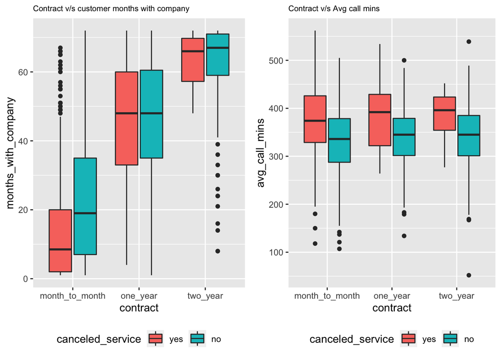

```r
contract_box <- ggplot(telecom_df, aes(x= contract, fill= canceled_service)) +
  geom_boxplot(aes(y = months_with_company)) +
  labs(title = "Contract v/s customer months with company") +
  theme(legend.position = "bottom",
        plot.title = element_text(size=8))

call_box <- ggplot(telecom_df, aes(x= contract,
                                   fill= canceled_service)) +
  geom_boxplot(aes(y = avg_call_mins)) +
  labs(title = "Contract v/s Avg call mins ") +
  theme(legend.position = "bottom",
        plot.title = element_text(size=8))

ggarrange(contract_box, call_box, nrow=1)
```

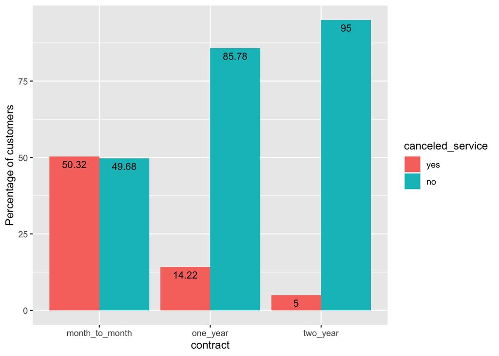

```r
contract_perc <- telecom_df %>%
  group_by(contract, canceled_service) %>%
  summarise(cnt = n()) %>%
  mutate(perct = round(cnt/sum(cnt)*100,2))

ggplot(contract_perc, aes(x = contract, y= perct,
                          fill= canceled_service)) +
  geom_bar(stat = "identity", position=position_dodge()) +
  geom_text(aes(label=perct), vjust=1.6, color="black",
            position = position_dodge(0.9), size=3.5) +
  ylab("Percentage of customers")
```

# Question 4

**Question**: Is the canceled service related to the cellular service and internet service?

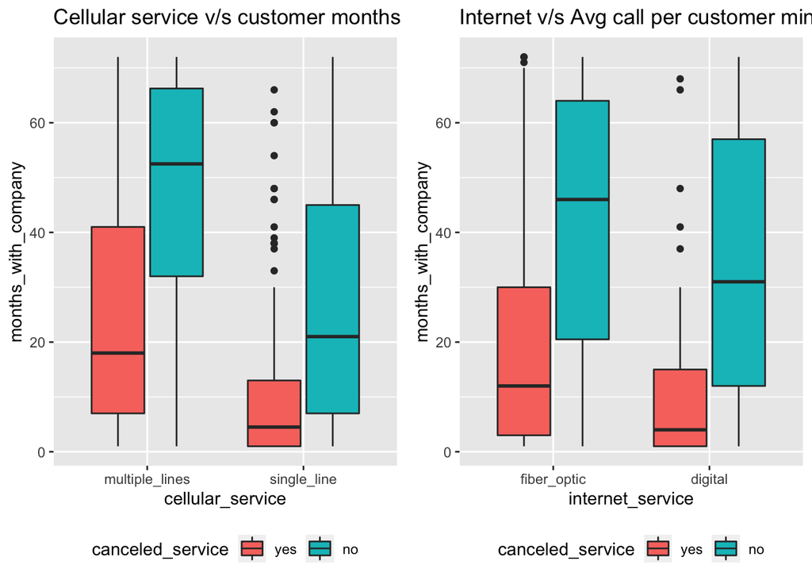

```r
cell_box <- ggplot(telecom_df, aes(x= cellular_service,
                                   y = months_with_company,
                                   fill= canceled_service)) +
  geom_boxplot() +
  labs(title = "Cellular service v/s customer months with company") +
  theme(legend.position = "bottom")

internet_box <- ggplot(telecom_df, aes(x= internet_service,
                                       y = months_with_company,
                                       fill= canceled_service)) +
  geom_boxplot() +
  labs(title = "Internet v/s Avg call per customer mins") +
  theme(legend.position = "bottom")

ggarrange(cell_box, internet_box, nrow=1)
```

# Question 5

**Question**: Is the the canceled service is related to the payment method and monthly charges?

**Answer**: There is a moderate relation between cancel_service, monthly-charge and payment method. The cancellation rate of the customer who prefers to pay by electronic check is around 50%.

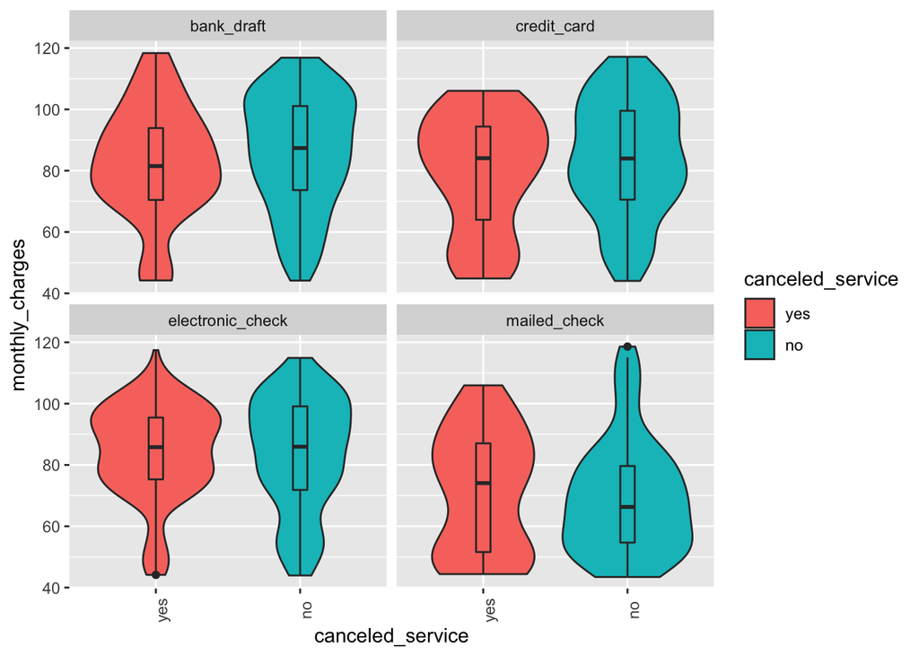

```r
charges_per <- telecom_df %>%
  group_by(payment_method, canceled_service) %>%
  summarise(count = n()) %>%
  mutate(per= prop.table(count) * 100)

ggplot(telecom_df, aes( x= canceled_service,
                        y = monthly_charges, fill = canceled_service) ) +
  geom_violin() +
  geom_boxplot(fill = NA, width = 0.1) +
  theme(axis.text.x = element_text(angle = 90))+
  facet_wrap(~ payment_method, nrow = 2)
```

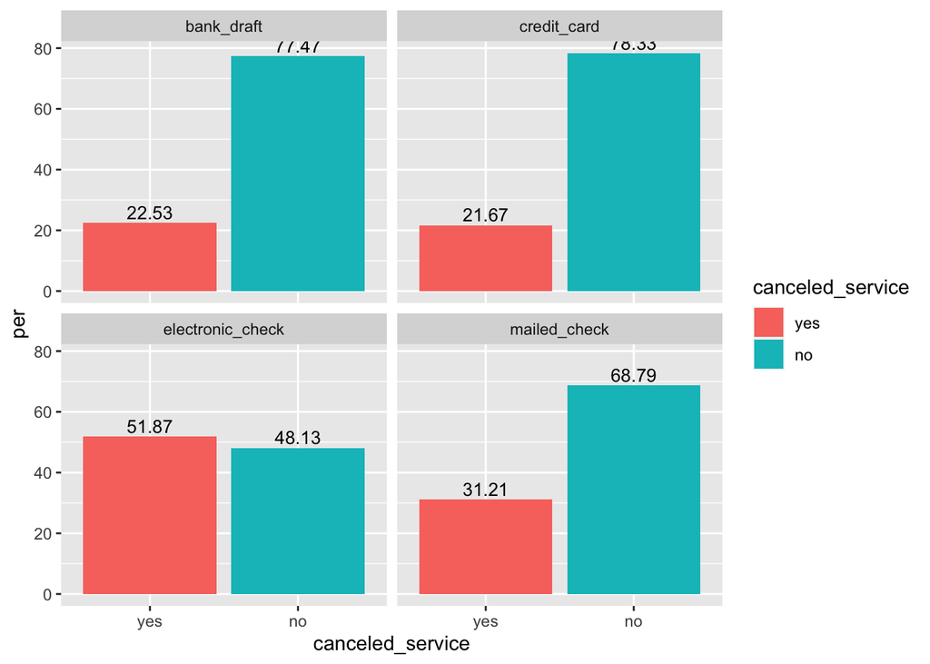

```r
ggplot(charges_per, aes(x = canceled_service, y= per, fill = canceled_service)) +
   geom_bar(stat = "identity") +
  geom_text(aes(label = round(per,digits =2)), vjust=-0.3, color="black", size=3.5) +
   facet_wrap(~ payment_method, nrow = 2)
```

# Model 1

##Logistic Regression

```r
## Data Splitting

set.seed(271)

telecom_split <- initial_split(telecom_df, prop = 0.75,
                               strata = canceled_service)

telecom_training <- telecom_split %>%
  training()

telecom_test <- telecom_split %>%
  testing()

# Cross validation folds for hyperparamter tuning

set.seed(271)

telecom_folds <- vfold_cv(telecom_training, v = 5)

## Feature Engineering

telecom_recipe <- recipe(canceled_service ~ .,
                         data = telecom_training) %>%
                 step_YeoJohnson(all_numeric(), -all_outcomes()) %>%
                 step_normalize(all_numeric(), -all_outcomes()) %>%
                 step_dummy(all_nominal(), -all_outcomes())

## Checking transformations

telecom_recipe %>%
  prep(training = telecom_training) %>%
  bake(new_data = NULL)
```

| avg_call_mins | avg_intl_mins | months_with_company | monthly_charges | canceled_service | senior_citizen_no | spouse_partner_no | dependents_no | cellular_service_single_line | internet_service_digital | online_security_no | online_backup_no | device_protection_no | tech_support_no | streaming_tv_no | streaming_movies_no | contract_one_year | contract_two_year | paperless_bill_no | payment_method_credit_card | payment_method_electronic_check | payment_method_mailed_check |
| --- | --- | --- | --- | --- | --- | --- | --- | --- | --- | --- | --- | --- | --- | --- | --- | --- | --- | --- | --- | --- | --- |
| -1.070608735 | 0.62213324 | -0.76594387 | -1.664597431 | no | 1 | 0 | 0 | 1 | 1 | 0 | 1 | 1 | 1 | 1 | 0 | 1 | 0 | 1 | 0 | 0 | 1 |
| 0.266965402 | 2.32821083 | 1.23586919 | 0.476482462 | no | 1 | 1 | 0 | 0 | 0 | 0 | 1 | 0 | 0 | 1 | 1 | 0 | 1 | 0 | 1 | 0 | 0 |
| 0.544997471 | -0.13196165 | -0.91954387 | -0.904004307 | no | 0 | 1 | 1 | 1 | 1 | 1 | 0 | 0 | 1 | 1 | 1 | 0 | 0 | 0 | 0 | 1 | 0 |
| 0.253149142 | -0.54357772 | 0.85286949 | 1.525891745 | no | 0 | 0 | 1 | 0 | 0 | 0 | 0 | 0 | 1 | 0 | 1 | 0 | 0 | 1 | 0 | 0 | 0 |
| -0.346336135 | 1.12129634 | -0.29320777 | 1.398043261 | no | 1 | 1 | 1 | 0 | 0 | 0 | 0 | 0 | 0 | 0 | 1 | 0 | 0 | 0 | 0 | 0 | 0 |
| -0.586595770 | -1.02182383 | -0.76594387 | -0.348945795 | no | 1 | 0 | 0 | 1 | 0 | 1 | 1 | 1 | 0 | 0 | 0 | 0 | 0 | 0 | 0 | 1 | 0 |
| -1.288250760 | -1.53667493 | 0.60351393 | 1.265237542 | no | 1 | 0 | 1 | 1 | 0 | 0 | 0 | 0 | 1 | 0 | 1 | 1 | 0 | 0 | 0 | 0 | 0 |
| -0.784461229 | -0.86197768 | 1.34367818 | -0.471632185 | no | 1 | 0 | 1 | 0 | 1 | 0 | 0 | 1 | 0 | 1 | 0 | 0 | 1 | 1 | 1 | 0 | 0 |
| -0.533466471 | 0.34015430 | 0.28375760 | -0.832264148 | no | 1 | 0 | 1 | 1 | 1 | 1 | 1 | 0 | 0 | 1 | 1 | 0 | 0 | 0 | 1 | 0 | 0 |
| 1.096147310 | 0.15164538 | -0.10611449 | -0.079913629 | no | 1 | 0 | 1 | 1 | 1 | 0 | 1 | 0 | 0 | 0 | 0 | 1 | 0 | 1 | 0 | 0 | 1 |

[output cut: 871 more lines]

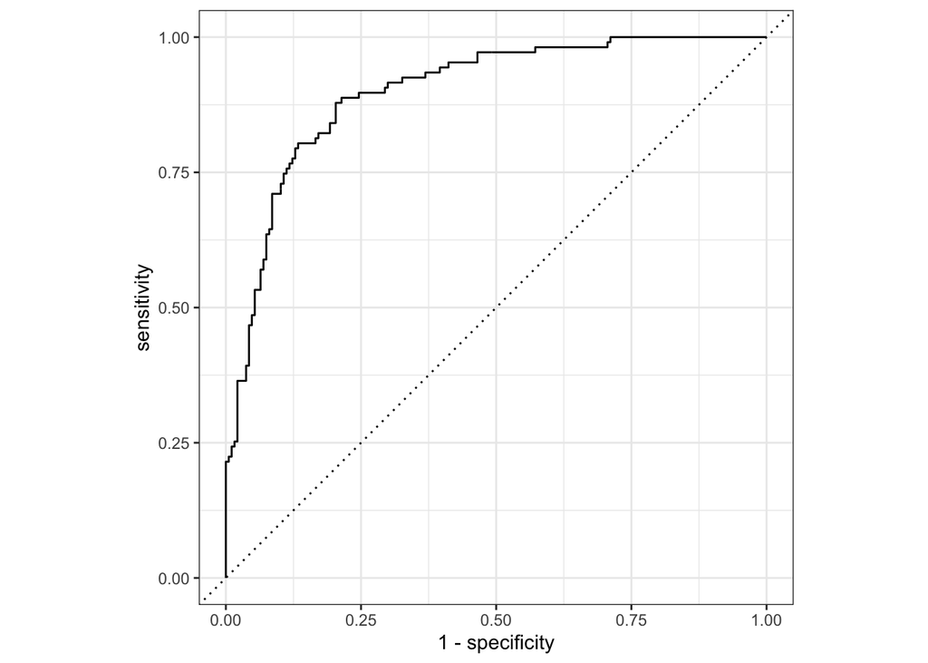

```r
## Specifying logistic regression model

logistic_model <- logistic_reg() %>%
                  set_engine('glm') %>%
                  set_mode('classification')

## Creating a workflow

logistic_wf <- workflow() %>%
               add_model(logistic_model) %>%
               add_recipe(telecom_recipe)

## Fitting a model
logistic_fit <- logistic_wf %>%
                last_fit(split = telecom_split)

## Collecting predictions
logistic_results <-  logistic_fit %>%
                     collect_predictions()

## Evaluating model performance
# ROC curve
roc_curve(logistic_results,
          truth = canceled_service,
          estimate = .pred_yes) %>%
  autoplot()
```

```r
# ROC AUC
roc_auc(logistic_results,
        truth = canceled_service,
        .pred_yes)
```

| .metric | .estimator | .estimate |
| --- | --- | --- |
| roc_auc | binary | 0.8996452 |

```r
# Confusion matrix
conf_mat(logistic_results,
         truth = canceled_service,
         estimate = .pred_class)
```

```
##           Truth
## Prediction yes  no
##        yes  82  23
##        no   25 164
```

# Model 2

## Linear Discriminant Analysis

```r
# Specifying LDA model

lda_model <- discrim_regularized(frac_common_cov = 1) %>%
             set_engine('klaR') %>%
             set_mode('classification')

# Creating LDA workflow

lda_wf <- workflow() %>%
          add_model(lda_model) %>%
          add_recipe(telecom_recipe)

# Fitting a model
lda_fit <- lda_wf %>%
  last_fit(split = telecom_split)

# Collect predictions
lda_fit %>% collect_metrics()
```

| .metric | .estimator | .estimate | .config |
| --- | --- | --- | --- |
| accuracy | binary | 0.8503401 | Preprocessor1_Model1 |
| roc_auc | binary | 0.9018442 | Preprocessor1_Model1 |

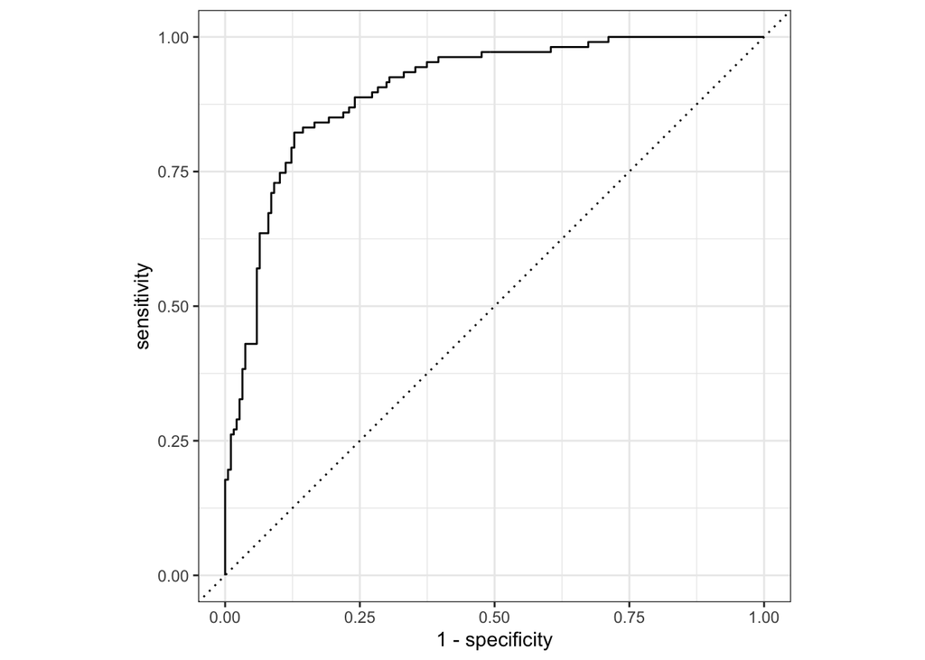

```r
lda_results <-  lda_fit %>%
                collect_predictions()


# Evaluating model performance

# ROC curve
roc_curve(lda_results,
          truth = canceled_service,
          estimate = .pred_yes) %>%
  autoplot()
```

```r
# ROC AUC
roc_auc(lda_results,
          truth = canceled_service,
          estimate = .pred_yes)
```

| .metric | .estimator | .estimate |
| --- | --- | --- |
| roc_auc | binary | 0.9018442 |

```r
# Confusion matrix
conf_mat(lda_results,
         truth = canceled_service,
         estimate = .pred_class)
```

```
##           Truth
## Prediction yes  no
##        yes  87  24
##        no   20 163
```

```r
f_meas(lda_results,
       truth = canceled_service,
         estimate = .pred_class)
```

| .metric | .estimator | .estimate |
| --- | --- | --- |
| f_meas | binary | 0.7981651 |

# Model 3

## KNN Classification

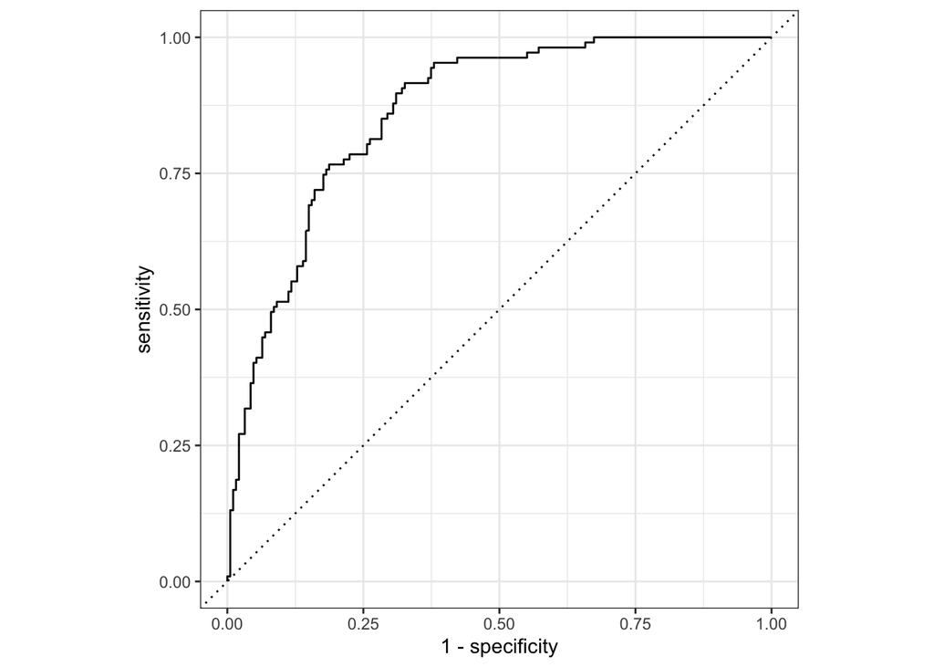

```r
# Specifying KNN model

knn_model <- nearest_neighbor(neighbors = tune()) %>%
             set_engine('kknn') %>%
             set_mode('classification')

# Creating KNN workflow

knn_wf <- workflow() %>%
  add_model(knn_model) %>%
  add_recipe(telecom_recipe)

# Tuning hyper parameter
## Create tuning grid

k_grid <- tibble(neighbors = c(10, 15, 25, 45, 60, 80, 100, 120, 140, 180))

## Grid search

set.seed(314)

knn_tuning <- knn_wf %>%
              tune_grid(resamples = telecom_folds,
                        grid = k_grid)

## Selecting best model

best_k <- knn_tuning %>%
          select_best(metric = 'roc_auc')

## Finalizing workflow

final_knn_wf <- knn_wf %>%
                finalize_workflow(best_k)

# Fit Model

knn_fit <- final_knn_wf %>%
           last_fit(split = telecom_split)

# Collecting predictions

knn_results <-  knn_fit %>%
                collect_predictions()

# Evaluating model performance

# ROC curve
roc_curve(knn_results,
          truth = canceled_service,
          estimate = .pred_yes) %>%
  autoplot()
```

```r
# ROC AUC
roc_auc(knn_results,
          truth = canceled_service,
          estimate = .pred_yes)
```

| .metric | .estimator | .estimate |
| --- | --- | --- |
| roc_auc | binary | 0.8631116 |

```r
# Confusion matrix
conf_mat(knn_results,
         truth = canceled_service,
         estimate = .pred_class)
```

```
##           Truth
## Prediction yes  no
##        yes  83  42
##        no   24 145
```

```r
## Model performance grade = B
```

# Model 4

## Random Forest

```r
# Model specification

rf_model <- rand_forest(mtry = tune(),
                        trees = tune(),
                        min_n = tune()) %>%
            set_engine('ranger', importance = "impurity") %>%
            set_mode('classification')

rf_workflow <- workflow() %>%
               add_model(rf_model) %>%
               add_recipe(telecom_recipe)

# Tuning hyper parameters

set.seed(314)

rf_grid <- grid_random(mtry() %>% range_set(c(2, 4)),
                       trees(),
                       min_n(),
                       size = 10)

rf_grid
```

| mtry | trees | min_n |
| --- | --- | --- |
| 3 | 1304 | 37 |
| 4 | 477 | 24 |
| 4 | 1621 | 32 |
| 4 | 1841 | 6 |
| 3 | 609 | 29 |
| 3 | 1235 | 16 |
| 4 | 1822 | 14 |
| 2 | 678 | 19 |
| 3 | 138 | 14 |
| 3 | 1218 | 4 |

```r
rf_tuning <- rf_workflow %>%
             tune_grid(resamples = telecom_folds,
                       grid = rf_grid)

# show 5 best models

rf_tuning %>% show_best('roc_auc')
```

| mtry | trees | min_n | .metric | .estimator | mean | n | std_err | .config |
| --- | --- | --- | --- | --- | --- | --- | --- | --- |
| 3 | 138 | 14 | roc_auc | binary | 0.8738105 | 5 | 0.01299321 | Preprocessor1_Model09 |
| 3 | 609 | 29 | roc_auc | binary | 0.8712533 | 5 | 0.01280432 | Preprocessor1_Model05 |
| 3 | 1235 | 16 | roc_auc | binary | 0.8709212 | 5 | 0.01305381 | Preprocessor1_Model06 |
| 3 | 1218 | 4 | roc_auc | binary | 0.8705623 | 5 | 0.01246238 | Preprocessor1_Model10 |
| 4 | 1822 | 14 | roc_auc | binary | 0.8705601 | 5 | 0.01370931 | Preprocessor1_Model07 |

```r
best_rf <- rf_tuning %>%
           select_best(metric = 'roc_auc')

best_rf
```

| mtry | trees | min_n | .config |
| --- | --- | --- | --- |
| 3 | 138 | 14 | Preprocessor1_Model09 |

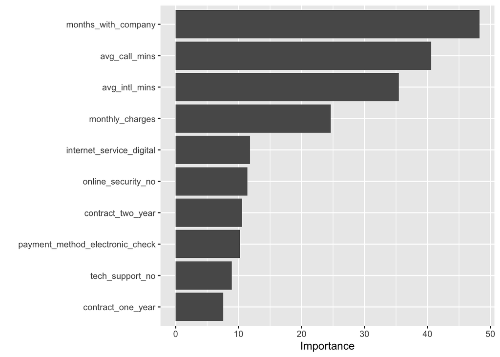

```r
# Finalize workflow

final_rf_workflow <- rf_workflow %>%
                     finalize_workflow(best_rf)

# Fit model

rf_wf_fit <- final_rf_workflow %>%
             fit(data = telecom_training)

rf_fit <- rf_wf_fit %>%
          pull_workflow_fit()
# Variable improtance
vip(rf_fit)
```

```r
# Train & evaluate last fit

rf_last_fit <- final_rf_workflow %>%
               last_fit(telecom_split)

rf_last_fit %>% collect_metrics()
```

| .metric | .estimator | .estimate | .config |
| --- | --- | --- | --- |
| accuracy | binary | 0.8197279 | Preprocessor1_Model1 |
| roc_auc | binary | 0.8878005 | Preprocessor1_Model1 |

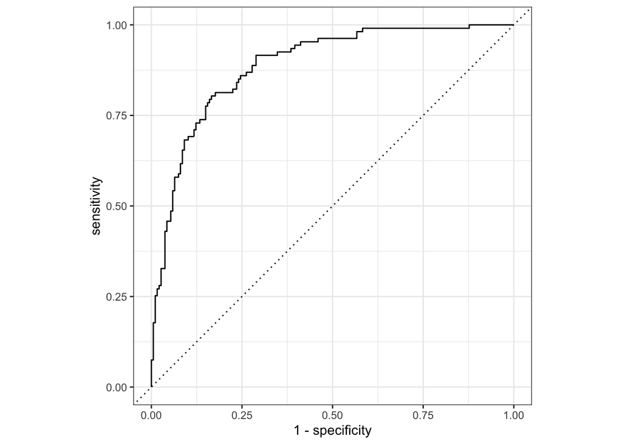

```r
# ROC curve

rf_last_fit %>% collect_predictions() %>%
                roc_curve(truth  =canceled_service,
                          estimate = .pred_yes) %>%
                autoplot()
```

```r
# Confusion matrix

rf_predictions <- rf_last_fit %>%
  collect_predictions()

conf_mat(rf_predictions, truth = canceled_service,
         estimate = .pred_class)
```

```
##           Truth
## Prediction yes  no
##        yes  76  22
##        no   31 165
```